# TSX Composite Index Price Prediction

Chetan Kumar, Student ID: 0702786

12/07/2021

# Background

S&P/TSX composite Index is Canadian equity market’s best known index. It summarizes a lot of data, share price of 233 Canada’s largest public companies. Most equity indexes are cap weighted. Where the cap is short for market capitalization. Indexes play an important role in the overall analysis of the equity markets. Indexes and their movements provide a great deal of insight into the economy, inversing the public’s risk appetite and the trends in investing diversification. Understanding what it indexes is, making following the financial market more interesting and more fun. The goal of this assignment is to analyse the future stock Index price of the TSX Composite using linear regression using OHLC (Open, High, Low, Close and Volume) data. These features are used by various prediction models which can be seen in “THE STOCK MARKET PREDICTION” SYSTEM research paper. Enormous research work has been concentrated on the feature prediction of stock prices based on historical prices and volume. Stock Price Trend Prediction Using Multiple Linear Regression research paper highlighted the use of a linear regression model to learn the trends of the market and then we predict the price of the stock, to give a brief idea about how the stock is going to perform.

Here, t-test will be performed on close price and other features of the stock market dataset. Same was done to analyse the impact of order effect when disclosing data in an experimental market setting.

An efficient stock market is a market where stock prices reflect fundamental information about companies. In such a case, the market value of the company changes in a way very similar to that of the intrinsic value of a company. These changes are not consistent with the value and do not restrain from trading financial assets. The differences in investor awareness and uneven transaction costs prevent fundamental changes in value to be completely and immediately reflected in market prices. This means, a market is efficient when it is not possible to earn a return higher than the market return. The efficient-market hypothesis suggests that stock prices reflect all currently available information and any price changes that are not based on newly revealed information thus are inherently unpredictable. Research paper on The Efficient Market Hypothesis: Review of Specialized Literature and Empirical Research is written on the same.A hypothesis which can predict the closing price of a stock on a particular day can become very handy for successful trading.

# Data Description

The dataset for this index is obtained from Yahoo Finance using the Quantmod package in R. The timeline of the data is from 01-Jan-2016 to 31-Dec-2019. After downloading the data we have 7 features: Open, High, Low, Close, Volume, Adjusted Close Price (of numeric class) and Date(of Date class). The ”open” is the price at which the asset started the day at. For example, if you are analyzing the TSX Composite index, the open price will be where the price starts the day. This price is determined by the demand and supply of the asset at the start of the day. High is the highest level the asset has reached. For example, if the TSX Composite index opened the day at $20,200, rose to a high of $20,270, and then started moving downwards, then the “high” of the day will be $20,270. As the name suggests, “Low” is the lowest price of the day. Finally, “Close” is the final price where the asset trades at. “Volume” is counted as the total number of shares that are actually traded (bought and sold) during the trading day or specified set period of time. It is a measure of the total turnover of shares. “Adjusted closing price” represents stock values which is just the cash value of the last transacted price before the market closes. The adjusted closing price factors in anything that might affect the stock price after the market closes. “Date” represents the date when the stock was traded.

```r
# Download symbol data
getSymbols("^GSPTSE", auto.assign=TRUE, from="2016-01-01", to="2019-12-31")
```

```
## [1] "^GSPTSE"
```

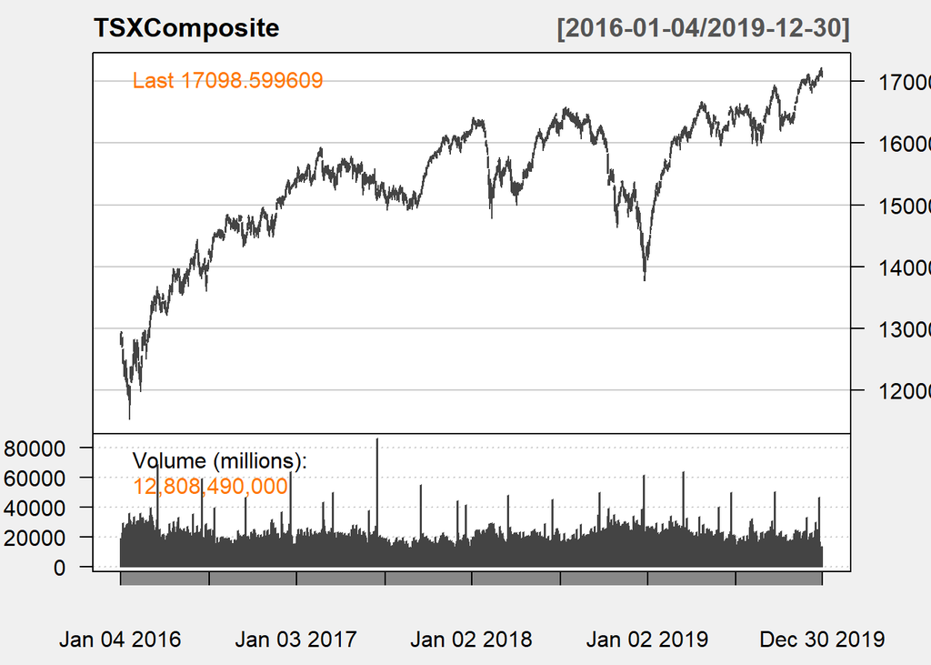

| Column Name | Description | Class |
| --- | --- | --- |
| Open | The Open price of the particular day | Numeric |
| High | The High price of the particular day | Numeric |
| Low | The Low price of the particular day | Numeric |
| Close | The Close price of the particular day | Numeric |
| Volume | Total Volume Traded on the particular day | Numeric |
| Adjusted Close Price | Adjusted Close Price at the end of the day | Numeric |
| Date | Date when stock was traded | Date |

```r
# Create a dataframe
TSX_Composite_Data <- as.data.frame(GSPTSE)
TSX_Composite_Data_gs <- TSX_Composite_Data
TSX_Composite_Data <- as.data.frame(TSX_Composite_Data)
# Add date field type "Date"
TSX_Composite_Data$Date <- time(GSPTSE)
# Rename names to proper format
names(TSX_Composite_Data) <- c("Open","High","Low","Close","Volume","Adjusted Close Price","Date")

names(TSX_Composite_Data_gs) <- c("Open","High","Low","Close","Volume","Adjusted Close Price")

# Plot CandleSticks of stock data
chartSeries(GSPTSE,theme="white",type = "candlesticks", name = "TSXComposite")
```

# Method

To conduct a two independent sample comparison of means test, I want to compare the average values of Open Price ,Low Price, High Price and Volume with Close price. Since Open price, Low Price,High Price are almost equal in mean and variance of close price so we will use only open price and Volume for t-test. We will conduct Welch’s t-test since it does not assume equal sample size or equal variance. Welch’s t-test remains robust for skewed distributions and large sample sizes. Reliability decreases for skewed distributions and smaller samples, where one could possibly perform Welch’s t-test. t-value measures the size of the difference relative to the variation in your sample data.The efficient-market hypothesis suggests that stock prices reflect all currently available information and any price changes that are not based on newly revealed information thus are inherently unpredictable.A hypothesis which can near about predict the closing price of a stock on a particular day can become very handy for successful trading. Our NULL hypothesis assumes that there is no impact of Volume, Open Price on Close Price and our alternate hypothesis assumes that there is an impact of Volume and Open price on close price.It is assumed that t-test performed does not impacted highly by open price,high price,low price,Adjusted Price on Close Price. Since we need to consider factors thant are not similar to close price. We assume Close price is highly dependent on Volume of the stock. I will use t.test() method to perform Welch’s two sided t-test.

```r
describe(TSX_Composite_Data)
```

```
##                      vars    n         mean           sd       median
## Open                    1 1002 1.541275e+04 1.038090e+03 1.554420e+04
## High                    2 1002 1.546375e+04 1.027160e+03 1.560610e+04
## Low                     3 1002 1.535533e+04 1.051660e+03 1.548495e+04
## Close                   4 1002 1.541131e+04 1.037260e+03 1.553965e+04
## Volume                  5 1002 2.154855e+10 6.896609e+09 2.080217e+10
## Adjusted Close Price    6 1002 1.541131e+04 1.037260e+03 1.553965e+04
## Date                    7 1002          NaN           NA           NA
##                           trimmed          mad     min          max
## Open                 1.553025e+04 9.828200e+02 11834.9 1.721620e+04
## High                 1.557977e+04 9.582000e+02 11932.4 1.723060e+04
## Low                  1.547418e+04 9.875600e+02 11531.2 1.714500e+04
## Close                1.552738e+04 9.827400e+02 11843.1 1.718020e+04
## Volume               2.095710e+10 4.410097e+09     0.0 8.588881e+10
## Adjusted Close Price 1.552738e+04 9.827400e+02 11843.1 1.718020e+04
## Date                          NaN           NA     Inf         -Inf
##                             range  skew kurtosis           se
## Open                 5.381300e+03 -1.01     0.88        32.79
## High                 5.298200e+03 -1.01     0.86        32.45
## Low                  5.613800e+03 -1.03     0.97        33.22
## Close                5.337100e+03 -1.01     0.89        32.77
## Volume               8.588881e+10  2.50    15.41 217872160.77
## Adjusted Close Price 5.337100e+03 -1.01     0.89        32.77
## Date                         -Inf    NA       NA           NA
```

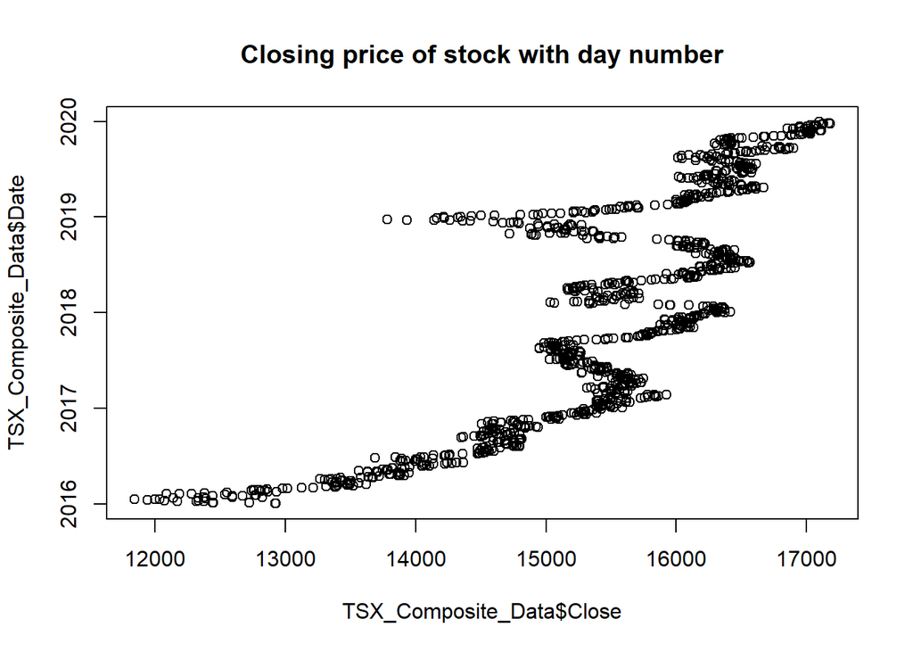

```r
plot(~TSX_Composite_Data$Close + TSX_Composite_Data$Date , main = "Closing price of stock with day number" , pch =1)
```

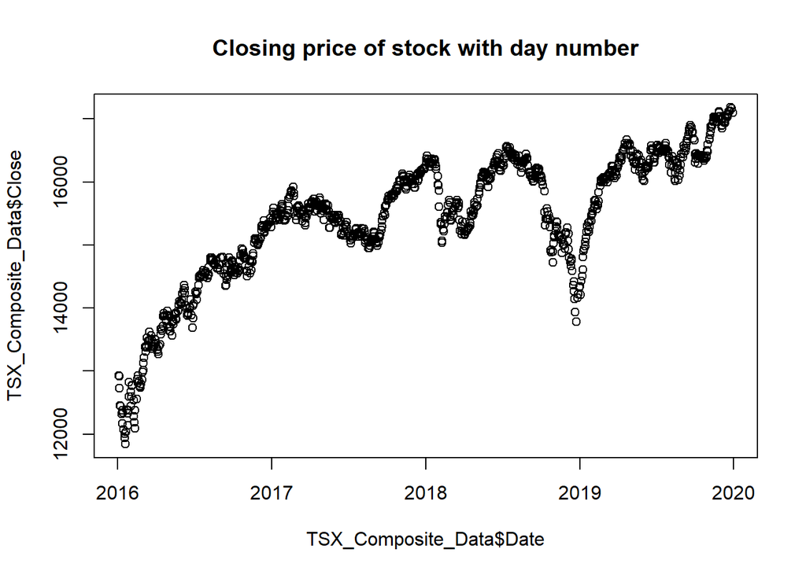

```r
plot(~TSX_Composite_Data$Date + TSX_Composite_Data$Close , main = "Closing price of stock with day number" , pch =1)
```

```r
# Correlation to check linearity component
cor(TSX_Composite_Data[,c(1:5)])
```

```
##              Open       High        Low      Close     Volume
## Open    1.0000000  0.9990997  0.9985580  0.9974352 -0.1952186
## High    0.9990997  1.0000000  0.9988088  0.9987932 -0.1914979
## Low     0.9985580  0.9988088  1.0000000  0.9990300 -0.2029998
## Close   0.9974352  0.9987932  0.9990300  1.0000000 -0.2000290
## Volume -0.1952186 -0.1914979 -0.2029998 -0.2000290  1.0000000
```

```r
# Welch's t-test on Open Price and Close Price
t.test(TSX_Composite_Data$Open, TSX_Composite_Data$Close)
```

```
##
##  Welch Two Sample t-test
##
## data:  TSX_Composite_Data$Open and TSX_Composite_Data$Close
## t = 0.030952, df = 2002, p-value = 0.9753
## alternative hypothesis: true difference in means is not equal to 0
## 95 percent confidence interval:
##  -89.48356  92.35340
## sample estimates:
## mean of x mean of y
##  15412.75  15411.31
```

```r
# Welch's t-test on Volumne and Close Price
t.test(TSX_Composite_Data$Volume, TSX_Composite_Data$Close)
```

```
##
##  Welch Two Sample t-test
##
## data:  TSX_Composite_Data$Volume and TSX_Composite_Data$Close
## t = 98.904, df = 1001, p-value < 2.2e-16
## alternative hypothesis: true difference in means is not equal to 0
## 95 percent confidence interval:
##  21120998037 21976075113
## sample estimates:
##    mean of x    mean of y
## 2.154855e+10 1.541131e+04
```

# Results

y = (1.957 * X1) + (-2.499e-08 * X2) -1.835e+04 + Error

Here, the slope Date is 1.957, Volume Slope is -2.499e-08 and the intercept of -1.835e+04.

```
##
## Call:
## lm(formula = TSX_Composite_Data$Close ~ TSX_Composite_Data$Date +
##     TSX_Composite_Data$Volume)
##
## Residuals:
##      Min       1Q   Median       3Q      Max
## -2445.55  -293.32    40.61   430.30  1774.06
##
## Coefficients:
##                             Estimate Std. Error t value Pr(>|t|)
## (Intercept)               -1.835e+04  7.904e+02  -23.21   <2e-16 ***
## TSX_Composite_Data$Date    1.957e+00  4.481e-02   43.67   <2e-16 ***
## TSX_Composite_Data$Volume -2.498e-08  2.736e-09   -9.13   <2e-16 ***
## ---
## Signif. codes:  0 '***' 0.001 '**' 0.01 '*' 0.05 '.' 0.1 ' ' 1
##
## Residual standard error: 596.5 on 999 degrees of freedom
## Multiple R-squared:   0.67,  Adjusted R-squared:  0.6693
## F-statistic:  1014 on 2 and 999 DF,  p-value: < 2.2e-16
```

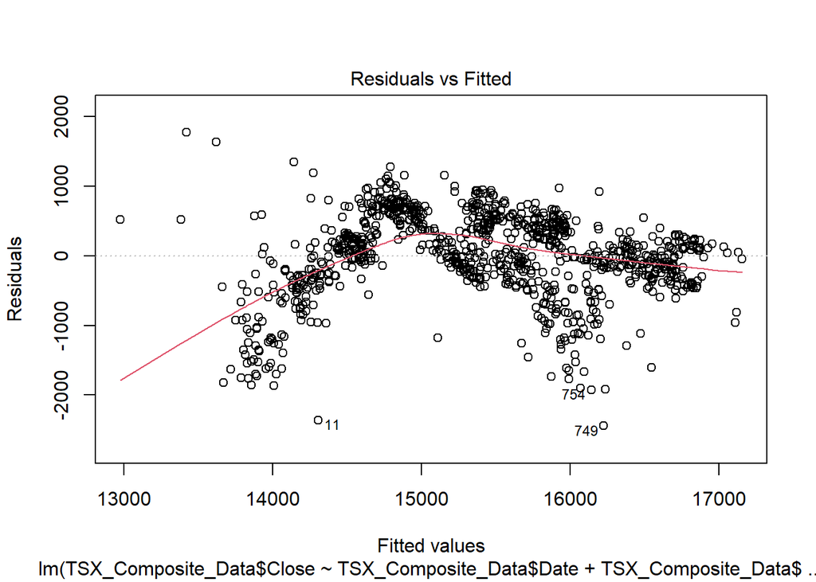

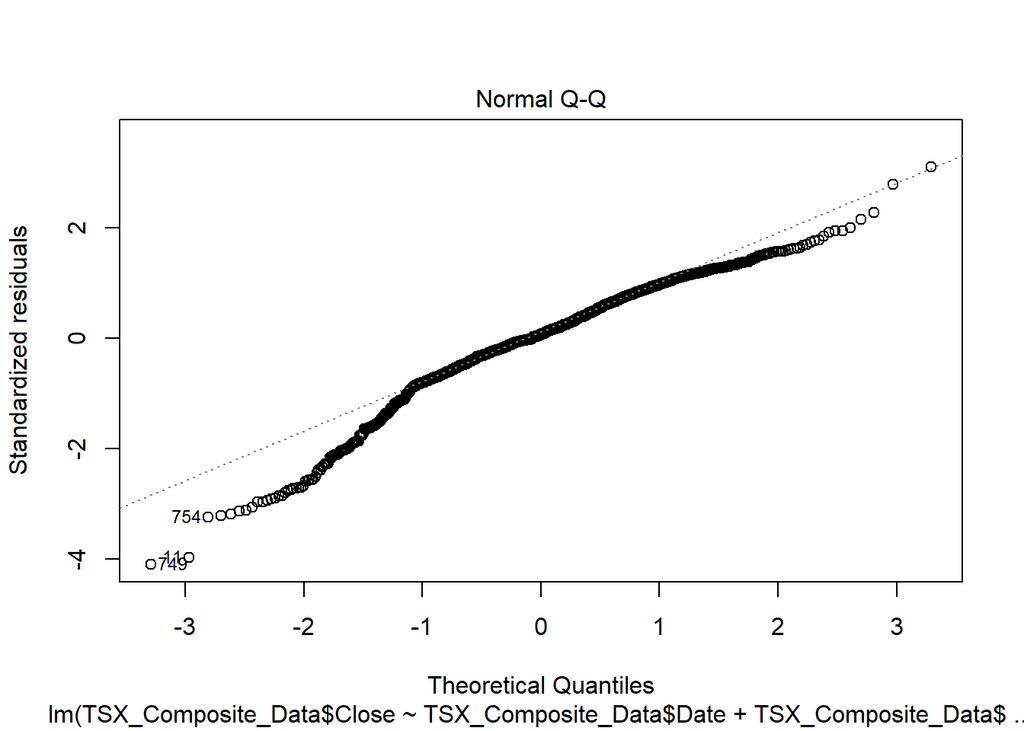

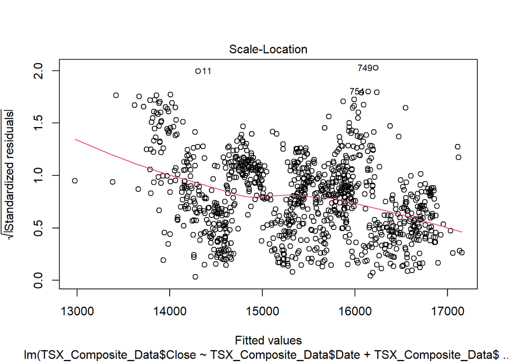

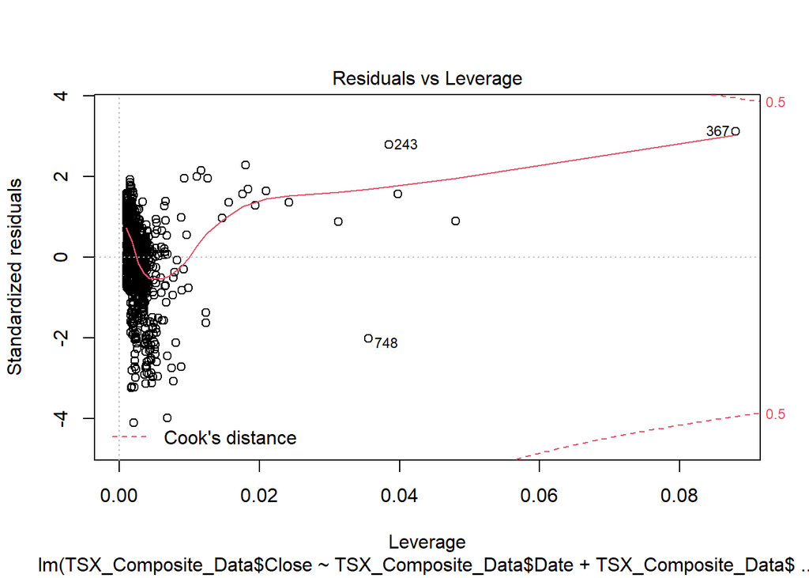

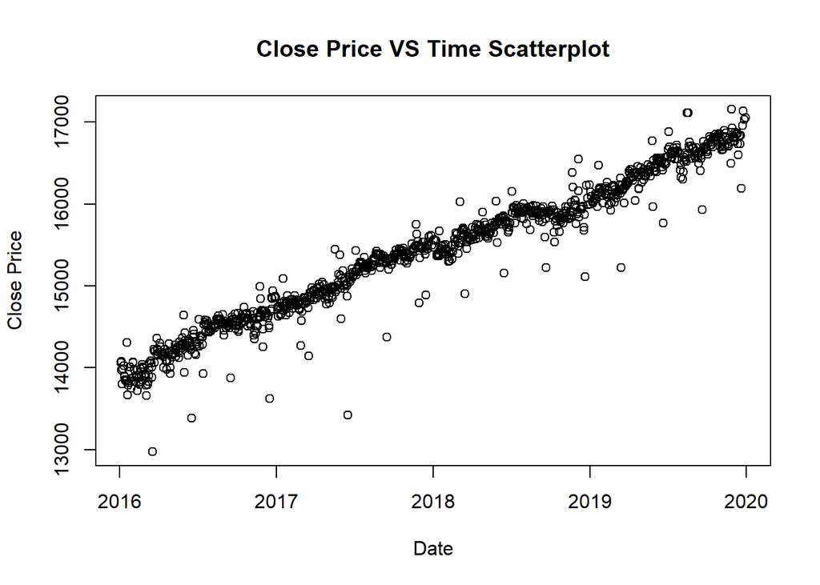

```
## [1] "MAPE : 354745.497643236"
```

```
## [1] "RMSE : 595.605152465319"
```

# Conclusion

Predicting Stock market is the act of trying to determine the future value of a company stock or other financial instrument traded on an exchange. I have used linear regression model to formulate my hypothesis to predict the closing price of the stock using past data. We can see that the pricing of the stock is not completely linearly dependent on the volume of the that date and Date of the trade. Such machine learning models indeed provide us with a broader understanding of the capital market. Hence we have harnessed this opportunity to gain an insight about the market.

We can see that the R-squared (also called the coefficient of determination) value is 0.6708 which is considered to be moderate. Date has a positive slope of 1.957 and Volume has a negative slope of -2.499e-08.Moreover, high MAPE and RMSE values indicates that the linear model is not the best fit to predict it as there is high errors. This seems obvious for linear regression to behave on the stock price in the market for a long period of time which does not allow the graph to be linear. I can further improve the modeling by doing Support Vector Regression, Neural Networks and many other models. Here, data from 2020 is not picked as due to COVID-19 stocks prices were declined which again reduces the effectiveness of using linear regression.

At the end, it means that market is not efficient, with proper analysis, using advance models and with advance computation and algorithm we can always beat the market and book large profits as we have seen the trend of non-linearity in various plots. With increase in momentum and volume of data traded, stock can perform better than the actual trend in the past.

**REFERENCES**

1. https://www.researchgate.net/publication/326253896_Analysis_of_stock_market_predictor_variables_using_linear_regression
2. https://www.researchgate.net/publication/351102391_THE_STOCK_MARKET_PREDICTION_SYSTEM
3. https://www.researchgate.net/publication/341322930_Stock_Price_Trend_Prediction_Using_Multiple_Linear_Regression
4. https://www.researchgate.net/publication/282509517_The_Impact_of_Order_Effects_on_Nonprofessional_Investors%27_Belief_Revision_When_Presented_a_Long_Series_of_Disclosures_in_an_Experimental_Market_Setting
5. https://www.researchgate.net/publication/289992792_The_Efficient_Market_Hypothesis_Review_of_Specialized_Literature_and_Empirical_Research

```r
# Take only the closing price
#daily_ts <- ts(TSX_Composite_Data_gs, start = decimal_date(as.Date("2016-01-01")), frequency = 365.25)

# daily_ts <- ts(TSX_Composite_Data_gs, start = c(2016,1), frequency = 365)
#
# head(daily_ts)
#
# #monthly_ts <- ts(TSX_Composite_Data_gs, start = decimal_date(as.Date("2016-01-01")), frequency = 12)
#
# monthly_ts <- ts(TSX_Composite_Data_gs, start = c(2016,1), frequency = 12)
#
# head(monthly_ts)
#
# #monthly_close <- Cl(to.monthly(TSX_Composite_Data_gs))
#
# #monthly_ts <- decompose(as.ts(monthly_close, start=c(2016,1), frequency = 12))
#
#
# window_daily <- window(daily_ts[,"Close"], start = decimal_date(as.Date("2016-1-1")))
#
#
# # Plot 1 : Seasonal Plot year wise (using ggseasonplot())
# ggseasonplot(window_daily, year.labels = TRUE) +
#   theme_minimal() +
#       theme(plot.background = element_rect("cornsilk2"),
#         panel.background = element_rect("khaki2"))+
#   ggtitle("Seasonal Plot: Daily Closing Price") +
#   ylab("(CAD)$")+
#   theme(panel.grid.major.x = element_blank(),
#         axis.title.x=element_blank(),
#         axis.text.x=element_blank(),
#         axis.ticks.x=element_blank())
#
#
# plot(monthly_ts)
#
#
#
# # Plot 2: Polar srasonal plot year-wise (using ggseasonalplot())
# ggseasonplot(close_daily_ts, polar = TRUE) +
#         ylab("degree") + ggtitle("Polar seasonal plot: Close Price Data")
```